# To Sink a Warship

Analyzing the Losses of the Imperial Japanese Navy

Matthew J. DiRisio (George Mason University)  
2019-05-06

The war in the Pacific during World War II (WWII) witnessed the advent of the aircraft carrier as the preeminent strike weapon, the maturation of United States Navy (USN) submarine forces, and the decline of traditional all-gun surface warships. All of these methods, and few others, combined to pummel the Imperial Japanese Navy (IJN) into submission by 1945. Traditionally, many WWII naval historians and scholars such as David Jones, Jim Christley, and Clay Blair have pointed to the USN submarine fleet as being a deciding factor. This approach has some merit when it comes to dissecting the losses of the Japanese maritime merchant fleet. However, when it comes to the IJN proper, the research in this paper seeks to lay out a case that it was actually the USN carrier fleet’s aircraft that did the true heavy lifting during the war. Although USN submarines sank more Japanese merchant ships, they were not as effective against the capital ships, such as aircraft carriers and battleships, of the IJN. This paper utilizes the extensive records of the Joint Army Navy Assessment Committee (JANAC) as a historical dataset to take a deeper look into IJN warship losses from 1941-1945, and sort through their causes of losses as well the method by which they were sunk.[^1] The JANAC was an inter-service United States Department of Defense program set up in 1943 to evaluate and measure Japanese naval and commercial ship losses caused by Allied forces during WWII. The cataloging of all Japanese Naval losses concluded in 1947 and established dates, tonnage, name, cause, sinking country, and sinking agents for every loss. This represents a significant source of previously untapped data, which correctly formatted, can be ran through R to gain a better understanding of change over time.[^2]

A more detailed look at the data yielded some interesting results. The data was pulled directly from the Naval History and Heritage Command Website. Without becoming too ensnared in the details, this was a relatively tedious process of copying and pasting the data into an Excel sheet, cleaning it, converting it into a Comma Separated Value (CSV) sheet, running it through Open Refine, and finally uploading it into R. It consists of 681 rows, each containing one IJN warship sunk during WWII and the relevant info concerning it. Although comprehensive, the data is thoroughly one-dimensional. It is simply a list of sunken naval warships, with some information on the specifics of sinking cause and what agent and country did the sinking. What the data does not do is answer the “why” or making any attempt to break down changing trends over time. The computational methods used by this article help to bridge the gap between the raw data of the JANAC and the actual operational processes which caused these outcomes. With a fair amount of refinement and cleaning, the data is more than sufficient to go some ways towards accomplishing this.

| id | date | name | type | tonnage | lat | lon | flag | agent |
| --- | --- | --- | --- | --- | --- | --- | --- | --- |
| 1 | 1941-12-10 | I 170 | submarine | 1785 | 23-45N | 155-35W | united_states | navy_carrier_based_aircraft |
| 2 | 1941-12-10 | MINESWEEPER NO 10 | minesweeper | 630 | 17-32N | 120-22E | united_states | land_based_aircraft |
| 3 | 1941-12-10 | MINESWEEPER NO 19 | minesweeper | 492 | 18-22N | 121-38E | united_states | land_based_aircraft |
| 4 | 1941-12-11 | HAYATE | escort | 1270 | 19-16N | 166-37E | united_states | shore_battery |
| 5 | 1941-12-11 | KISARAGI | escort | 1500 | 19-16N | 166-37E | united_states | shore_battery |
| 6 | 1941-12-17 | RO 66 | submarine | 988 | 19-25N | 166-30E | japan | marine_casualty |
| 7 | 1941-12-18 | SHINONOME | escort | 1950 | 4-24N | 114-00E | netherlands | mine |
| 8 | 1941-12-22 | PATROL BOAT NO 32 | escort | 750 | 19-17N | 166-35E | japan | marine_casualty |
| 9 | 1941-12-22 | PATROL BOAT NO 33 | escort | 750 | 19-17N | 166-35E | japan | marine_casualty |
| 10 | 1941-12-24 | SAGIRI | escort | 1950 | 1-34N | 110-21E | netherlands | submarine |

[output cut: 671 more lines]

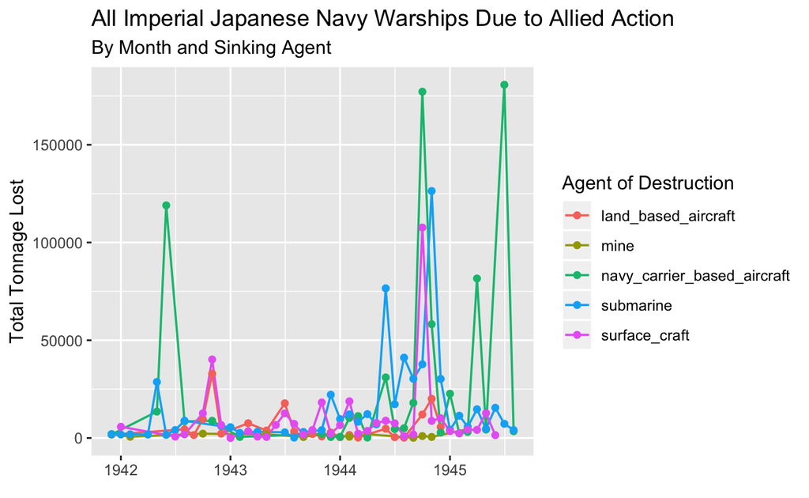

[^1]: The Joint Army-Navy Assessment Committee, NAVEXOS P 468, *Japanese Naval and Merchant Shipping Losses During World War II by All Causes*, February, 1947 https://www.history.navy.mil/research/library/online-reading-room/title-list-alphabetically/j/japanese-naval-merchant-shipping-losses-wwii.html
[^2]: For examples of typical USN histories highlighting submarines see Clay Blair, *Silent Victory: The U.S. Submarine War Against Japan*. (Annapolis: Naval Institute Press, 2001), David Jones, *U.S. Subs Down Under. Brisbane, 1942–1945* (Annapolis: Naval Institute Press, 2005), and Jim Christley, *US Submarines 1941–45* (Oxford: Ospery Publishing, 2006)